# Ramadan estimation

```r
                  esp <- lapply(resul, "[[", "ciLZ")
                  esp <- lapply(esp, as.matrix)
                  esprn <- unlist(lapply(esp, rownames))
                  esp <- lapply(esp, function(x) as.data.table(x[, ]))
                  esp <- lapply(1:length(esp), function(i) esp[[i]][, reg := i])
                  dfs <- lapply(resul, "[[", "df")
                  esp <- lapply(1:length(esp), function(i) esp[[i]][, df := dfs[[i]]])
                  esp <- lapply(1:length(esp), function(i) esp[[i]][, n := ns[i]])
                  esp <- lapply(1:length(esp), function(i) esp[[i]][, R2 := Rs[i]])
                  esp <- rbindlist(esp, use.names = T, fill = T)
                  if (any(grepl("z value", colnames(esp)))) esp[, "z value" := NULL]
                  estlz <- lapply(resul, "[[", "estLZ")
                  estlz <- lapply(estlz, as.matrix)
                  estrn <- unlist(lapply(estlz, rownames))
                  estlz <- lapply(estlz, function(x) as.data.table(x[, ]))
                  estlz <- rbindlist(estlz, use.names = T, fill = T)
                  ciLZ <- cbind(Coef = estrn, estlz, esp)
                  setnames(ciLZ,  c("Coef", "beta", "SE", "t", "p_val", "CI_L", "CI_U", "reg", "df", "n", "R2"))
                  ciLZ[, t := NULL]
                  ciLZ[, inference := "LZ"]
                  cis <- rbindlist(list(ciBRL, ciLZ), use.names = T)
                  cis[, data := zSobj[jj]]
                  cis[, HHtype := c("all", "direct")[j]]
                  cis[, agdef := aghh.defs[m]]
                  cis[, agelb := s0]
                  cis[, year := sampleyears[yy]]
                  cis[, sample := c("contemporaneous", "all time")[rr]]
                  cis[, gender := genderitems[ge]]
                  CIs <- rbind(CIs, cis)
                  enrr <- zr[, .(MeanDaysAbsent = mean(DaysAbsent), Num = .N), by = agHH]
                  DaysAbsent <- rbind(DaysAbsent,
                    cbind(zSobj[jj], c("all", "nuclear")[j],
                      sampleyears[yy], c("contemporaneous", "all time")[rr],
                      c("default", aghh.defs[-1])[m],
                      c("boys", "girls", "boys+girls")[ge],
                      s0, enrr),
                    use.names = F
                  )
                  # Save mean progression rate changes
                  # x: agHH, y: nonagHH
                  ttestE <- t.test(zr[agHH == 1L, DaysAbsent], zr[agHH == 0L, DaysAbsent])
                  DaysAbsentchg <- rbind(DaysAbsentchg,
                    cbind(
                        zSobj[jj], c("all", "nuclear")[j],
                        sampleyears[yy], c("contemporaneous", "all time")[rr],
                        c("default", aghh.defs[-1])[m],
                        c("boys", "girls", "boys+girls")[ge],
                        s0, round(-diff(unlist(ttestE["estimate"])), 3), # -diff = -(y - x) = AgHH - nonagHH
                        t(as.numeric(unlist(lapply(ttestE[c("estimate", "conf.int", "p.value")], round, 4))))
                        )
                      )
                }  # m: ag HH definitions
              } # ge: gender
            }  # j: z2 (incl. extended) or z3 (nuclear)
          }  # s: upperbound age cutoffs (10, 15)
      } # yy: 1999 or 2002
    } # rr: 1 contemporanesou enroller or 2 all time enroller
  }  # jj: zE / zS sample selection
  results[[ii]] <- results0
}  # ii: main / placebo samples
#### results: Results under same obs with BRL (satterthwaith dof) information
#### inference is not given unique level clnum. Each k spec has ciLZ and ciBRL.
#### results[[ii]][[jj]][[yy]][[rr]][[s]][[j]][[ge]][[m]]
#### resultsN: Results under varying number of obs between specifications
#### https://cran.r-project.org/web/packages/qs/vignettes/vignette.html
setcolorder(CIs,  c("data", "sample", "year", "HHtype", "agdef", "agelb", "gender", "reg", "n", "df", "R2", "inference",
   "Coef", "beta", "SE", "p_val", "CI_L", "CI_U"))
thesecols <- c("n", "df", "R2", "beta", "SE", "p_val", "CI_L", "CI_U")
CIs[, (thesecols) := lapply(.SD, as.numeric), .SDcols = thesecols]
thesecols <- colnames(CIs)[!colnames(CIs) %in% thesecols]
CIs[, (thesecols) := lapply(.SD, as.factor), .SDcols = thesecols]
library(qs)
qsave(results, "../save/DID2024_DaysAbsentCrossSectionResults.qs")
qsave(CIs, "../save/DID2024_DaysAbsentCrossSectionCIs.qs")

DaysAbsent <- data.table(DaysAbsent)
DaysAbsentchg <- data.table(DaysAbsentchg)
setnames(DaysAbsentchg, c("data", "HHtype", "year", "sample", "agHHdef",
  "gender", "agelb", "AgNonag", "agHH", "nonagHH", "lb95", "ub95", "pvalue"))
setnames(DaysAbsent, c("data", "HHtype", "year", "sample", "agHHdef", "gender", "agelb",
   "agHH",  "rate", "Obs"))
DaysAbsent[, gender := factor(gender, levels=genderitems)]
DaysAbsent[, agHHdef := factor(agHHdef, levels=aghh.defs)]
qsave(DaysAbsent, "../save/DaysAbsent2024CrossSection.qs")
qsave(DaysAbsentchg, "../save/DaysAbsentchg2024CrossSection.qs")
```

# Results

## Main estimation results

Main results: Enrollment impacts for year 1999-2002, 10-18 years old, direct offspring, Satterthwaite correction

| variables | Agricultural HHs raw DID | Agricultural HHs +covariates+Thana trends | Agricultural HHs +HH trends | Agricultural HHs (head) raw DID | Agricultural HHs (head) +covariates+Thana trends | Agricultural HHs (head) +HH trends |
| --- | --- | --- | --- | --- | --- | --- |
| **Boys+Girls** |  |  |  |  |  |  |
|  | 1 | 2 | 3 | 4 | 5 | 6 |
| Agricultural household | -0.042 | -0.057 | -0.077 | -0.090 | -0.076 | -0.085 |
|  | (38.8) | (7.7) | (3.2) | (8.8) | (2.6) | (2.3) |
|  | [-0.151, 0.067] | [-0.123, 0.008] | [-0.144, -0.009] | [-0.197, 0.018] | [-0.140, -0.012] | [-0.153, -0.016] |
| Older female siblings |  |  | -0.029 |  |  | -0.028 |
|  |  |  | (44.4) |  |  | (43.0) |
|  |  |  | [-0.119, 0.062] |  |  | [-0.113, 0.057] |
| Older male siblings |  |  | -0.096 |  |  | -0.057 |
|  |  |  | (11.9) |  |  | (28.8) |
|  |  |  | [-0.229, 0.036] |  |  | [-0.179, 0.064] |
| R2 | 0.0018 | 0.4421 | 0.4839 | 0.0085 | 0.4446 | 0.4839 |
| N: agHH |  | 384 |  |  | 346 |  |
| N |  | 626 |  |  | 626 |  |
| mean of control in 1999 |  | 0.7769 |  |  | 0.7464 |  |
| mean of treated in 1999 |  | 0.7135 |  |  | 0.7312 |  |
| mean of control in 2002 |  | 0.4959 |  |  | 0.4893 |  |
| mean of treated in 2002 |  | 0.3906 |  |  | 0.3844 |  |
| **Boys** |  |  |  |  |  |  |
|  | 7 | 8 | 9 | 10 | 11 | 12 |
| Agricultural household | -0.097 | -0.129 | -0.120 | -0.175 | -0.152 | -0.144 |
|  | (24.2) | (3.5) | (1.8) | (6.9) | (0.9) | (0.1) |
|  | [-0.280, 0.085] | [-0.245, -0.012] | [-0.211, -0.029] | [-0.368, 0.019] | [-0.251, -0.053] | [-0.206, -0.083] |
| Older female siblings |  |  | -0.111 |  |  | -0.082 |
|  |  |  | (3.7) |  |  | (10.7) |
|  |  |  | [-0.210, -0.011] |  |  | [-0.189, 0.026] |
| Older male siblings |  |  | -0.052 |  |  | -0.006 |
|  |  |  | (41.9) |  |  | (91.1) |
|  |  |  | [-0.209, 0.105] |  |  | [-0.128, 0.117] |
| R2 | 0.0096 | 0.3662 | 0.4148 | 0.0328 | 0.3738 | 0.4199 |
| N: agHH |  | 197 |  |  | 177 |  |
| N |  | 306 |  |  | 306 |  |
| mean of control in 1999 |  | 0.7156 |  |  | 0.6512 |  |
| mean of treated in 1999 |  | 0.6396 |  |  | 0.6780 |  |
| mean of control in 2002 |  | 0.4679 |  |  | 0.4419 |  |
| mean of treated in 2002 |  | 0.2944 |  |  | 0.2938 |  |
| **Girls** |  |  |  |  |  |  |
|  | 13 | 14 | 15 | 16 | 17 | 18 |
| Agricultural household | 0.009 | -0.024 | -0.047 | -0.010 | -0.029 | -0.042 |
|  | (90.5) | (74.6) | (56.7) | (83.8) | (66.3) | (58.5) |
|  | [-0.163, 0.180] | [-0.200, 0.152] | [-0.240, 0.145] | [-0.119, 0.100] | [-0.187, 0.128] | [-0.223, 0.138] |
| Older female siblings |  |  | 0.029 |  |  | 0.009 |
|  |  |  | (77.1) |  |  | (93.1) |
|  |  |  | [-0.219, 0.277] |  |  | [-0.248, 0.266] |
| Older male siblings |  |  | -0.091 |  |  | -0.072 |
|  |  |  | (15.1) |  |  | (22.2) |
|  |  |  | [-0.231, 0.048] |  |  | [-0.204, 0.060] |
| R2 | 0.0001 | 0.5925 | 0.6104 | 0.0001 | 0.5928 | 0.6084 |
| N: agHH |  | 187 |  |  | 169 |  |
| N |  | 320 |  |  | 320 |  |
| mean of control in 1999 |  | 0.8271 |  |  | 0.8278 |  |
| mean of treated in 1999 |  | 0.7914 |  |  | 0.7870 |  |
| mean of control in 2002 |  | 0.5188 |  |  | 0.5298 |  |
| mean of treated in 2002 |  | 0.4920 |  |  | 0.4793 |  |
| **Common specifications** |  |  |  |  |  |  |
| Covariates, thana trends |  | Y | Y |  | Y | Y |
| HH trends |  |  | Y |  |  | Y |

Note:

Sample of direct offspring of household heads.

<sup>1</sup> For each panel, first and fourth columns are raw DID. Second and fifth columns add time-varying thana level characteristics (yield, mean rainfall, mean high temperature, mean low temperature), individual level characteristics (age squared, recipient of a poverty program), and Thana fixed trends that are interactions of year 2002 dummy with Thana fixed effects. Third and sixth columns add interactions of year 2002 dummy and individual level characterstics (sex of individual, household head’s and spouse’s education, number of older male/female siblings, per member land holding, per member non land asset holding, piped water access, structured toilet access) $\bfx_{i}r_{t}$, and triple interactions of year 2002 dummy, individual characteristics, and agricultural household dummy $\bfx_{i}r_{t}D_{i}$.

<sup>2</sup> Standard errors are clusterd at thana level using bias-reduced linearization (Satterthwaite correction) for a correction of small number of clusters. $P$ values in percentages are shown in parethenses. 95% confidence intervals are shown in square brackets. $*$, $**$, $***$ indicate significance levels at 10%, 5%, 1% under BRL cluster robust standard errors, respectively.

- Impacts under our default agHH definition have larger SEs. This is due to possible measurement errors in occupation based definition, which is incorporated in our default definition.
- Impacts are most strongly found among boys.
- Impacts on girls are negative, but the size is small and estimates are noisy.
- Note: Corr(lowMeanY, highMeanY)=.193 using regression data for boys, nuclear, 10 - 18. So the estimates on these covariates are not suffering from biases arising from multicollinearity.

## Age group wise estimation results

Main results: Enrollment impacts for year 1999-2002 by school age group, direct offspring, Satterthwaite correction

| variables | boys+girls raw DID | boys+girls +covariates+Thana trends | boys+girls +HH trends | boys raw DID | boys +covariates+Thana trends | boys +HH trends | girls raw DID | girls +covariates+Thana trends | girls +HH trends |
| --- | --- | --- | --- | --- | --- | --- | --- | --- | --- |
| **Primary** |  |  |  |  |  |  |  |  |  |
|  | 1 | 2 | 3 | 4 | 5 | 6 | 7 | 8 | 9 |
| Agricultural household | -0.005 | 0.010 | -0.000 | 0.094 | 0.052 | 0.077 | -0.094 | -0.039 | -0.082 |
|  | (92.4) | (76.1) | (99.8) | (39.9) | (41.8) | (30.9) | (0.7) | (45.7) | (22.4) |
|  | [-0.119, 0.109] | [-0.064, 0.084] | [-0.105, 0.105] | [-0.155, 0.343] | [-0.093, 0.196] | [-0.096, 0.249] | [-0.153, -0.035] | [-0.159, 0.080] | [-0.228, 0.064] |
| Older female siblings |  |  | 0.050 |  |  | 0.034 |  |  | 0.077 |
|  |  |  | (43.9) |  |  | (64.5) |  |  | (43.9) |
|  |  |  | [-0.101, 0.201] |  |  | [-0.138, 0.206] |  |  | [-0.166, 0.320] |
| Older male siblings |  |  | -0.057 |  |  | -0.097 |  |  | -0.011 |
|  |  |  | (23.5) |  |  | (4.4) |  |  | (86.5) |
|  |  |  | [-0.163, 0.049] |  |  | [-0.191, -0.003] |  |  | [-0.160, 0.138] |
| R2 | 0.0000 | 0.3837 | 0.4111 | 0.0076 | 0.3960 | 0.4511 | 0.0085 | 0.4081 | 0.4363 |
| N: agHH |  | 295 |  |  | 154 |  |  | 141 |  |
| N |  | 507 |  |  | 253 |  |  | 254 |  |
| mean of control in 1999 |  | 0.8255 |  |  | 0.8586 |  |  | 0.7965 |  |
| mean of treated in 1999 |  | 0.8000 |  |  | 0.7792 |  |  | 0.8227 |  |
| mean of control in 2002 |  | 0.8302 |  |  | 0.7778 |  |  | 0.8761 |  |
| mean of treated in 2002 |  | 0.8000 |  |  | 0.7922 |  |  | 0.8085 |  |
| **Secondary** |  |  |  |  |  |  |  |  |  |
|  | 10 | 11 | 12 | 13 | 14 | 15 | 16 | 17 | 18 |
| Agricultural household | -0.061 | -0.083 | -0.090 | -0.152 | -0.173 | -0.142 | 0.013 | -0.029 | -0.086 |
|  | (18.4) | (4.9) | (2.4) | (3.5) | (0.3) | (1.0) | (85.5) | (70.5) | (17.8) |
|  | [-0.160, 0.038] | [-0.165, -0.000] | [-0.163, -0.017] | [-0.290, -0.015] | [-0.260, -0.086] | [-0.234, -0.050] | [-0.153, 0.180] | [-0.205, 0.148] | [-0.225, 0.052] |
| Older female siblings |  |  | -0.028 |  |  | -0.123 |  |  | 0.040 |
|  |  |  | (66.4) |  |  | (9.7) |  |  | (73.0) |
|  |  |  | [-0.186, 0.130] |  |  | [-0.278, 0.032] |  |  | [-0.247, 0.327] |
| Older male siblings |  |  | -0.071 |  |  | 0.010 |  |  | -0.119 |
|  |  |  | (26.3) |  |  | (87.6) |  |  | (17.8) |
|  |  |  | [-0.217, 0.076] |  |  | [-0.153, 0.172] |  |  | [-0.318, 0.080] |
| R2 | 0.0037 | 0.4673 | 0.5235 | 0.0237 | 0.3926 | 0.4660 | 0.0002 | 0.6104 | 0.6460 |
| N: agHH |  | 301 |  |  | 148 |  |  | 153 |  |
| N |  | 486 |  |  | 228 |  |  | 258 |  |
| mean of control in 1999 |  | 0.7459 |  |  | 0.6750 |  |  | 0.8000 |  |
| mean of treated in 1999 |  | 0.6877 |  |  | 0.5878 |  |  | 0.7843 |  |
| mean of control in 2002 |  | 0.4649 |  |  | 0.4625 |  |  | 0.4667 |  |
| mean of treated in 2002 |  | 0.3455 |  |  | 0.2230 |  |  | 0.4641 |  |
| **Common specifications** |  |  |  |  |  |  |  |  |  |
| Covariates, thana trends |  | Y | Y |  | Y | Y |  | Y | Y |
| HH trends |  |  | Y |  |  | Y |  |  | Y |

Note:

Sample of direct offspring of household heads.

<sup>1</sup> For each panel, first, fourth, and seventh columns are raw DID. Second, fifth, and eith columns add time-varying thana level characteristics (yield, mean rainfall, mean high temperature, mean low temperature), individual level characteristics (age squared, recipient of a poverty program), and Thana fixed trends that are interactions of year 2002 dummy with Thana fixed effects. Third, sixth, and ninth columns add interactions of year 2002 dummy and individual level characterstics (sex of individual, household head’s and spouse’s education, number of older male/female siblings, per member land holding, per member non land asset holding, piped water access, structured toilet access) $\bfx_{i}r_{t}$, and triple interactions of year 2002 dummy, individual characteristics, and agricultural household dummy $\bfx_{i}r_{t}D_{i}$.

<sup>2</sup> Standard errors are clusterd at thana level with a correction for small number of clusters using bias reduced linearization (Satterthwaite correction). $P$ values in percentages are shown in parethenses. 95% confidence intervals are shown in square brackets.

- Results show that main effects are found among secondary school goers, mostly boys.
- Primary school aged children may be too young to get affected.
- Looking from a different subsample, results by different age lowerbound in the appendix show impacts to be larger among the sample with older boys.

## Placebo estimation results

Enrollment placebo impacts: Year 2002-2006, 10-18 years old, direct offspring, Satterthwaite correction

| variables | Agricultural HHs raw DID | Agricultural HHs +covariates+Thana trends | Agricultural HHs +HH trends | Agricultural HHs (head) raw DID | Agricultural HHs (head) +covariates+Thana trends | Agricultural HHs (head) +HH trends |
| --- | --- | --- | --- | --- | --- | --- |
| **2002 cohort: Boys+girls** |  |  |  |  |  |  |
|  | 1 | 2 | 3 | 4 | 5 | 6 |
| Agricultural household | -0.053 | -0.030 | -0.044 | -0.048 | -0.023 | -0.037 |
|  | (14.2) | (40.6) | (35.7) | (16.8) | (53.0) | (35.5) |
|  | [-0.129, 0.023] | [-0.112, 0.051] | [-0.149, 0.062] | [-0.121, 0.026] | [-0.105, 0.060] | [-0.125, 0.052] |
| Older female siblings |  |  | -0.071 |  |  | -0.073 |
|  |  |  | (6.4) |  |  | (10.4) |
|  |  |  | [-0.148, 0.006] |  |  | [-0.167, 0.021] |
| Older male siblings |  |  | 0.012 |  |  | 0.003 |
|  |  |  | (71.9) |  |  | (93.2) |
|  |  |  | [-0.069, 0.094] |  |  | [-0.086, 0.093] |
| R2 | 0.0030 | 0.2022 | 0.2250 | 0.0025 | 0.2019 | 0.2197 |
| N: agHH |  | 492 |  |  | 440 |  |
| N |  | 812 |  |  | 812 |  |
| mean of control in 2002 |  | 0.6844 |  |  | 0.6747 |  |
| mean of treated in 2002 |  | 0.5955 |  |  | 0.5932 |  |
| mean of control in 2006 |  | 0.4406 |  |  | 0.4247 |  |
| mean of treated in 2006 |  | 0.2988 |  |  | 0.2955 |  |
| **2002 cohort: Boys** |  |  |  |  |  |  |
|  | 7 | 8 | 9 | 10 | 11 | 12 |
| Agricultural household | 0.004 | -0.020 | -0.029 | -0.004 | -0.027 | -0.045 |
|  | (93.5) | (57.9) | (35.6) | (94.6) | (48.6) | (29.0) |
|  | [-0.098, 0.105] | [-0.100, 0.061] | [-0.098, 0.041] | [-0.127, 0.120] | [-0.115, 0.061] | [-0.140, 0.049] |
| Older female siblings |  |  | -0.098 |  |  | -0.102 |
|  |  |  | (13.7) |  |  | (10.7) |
|  |  |  | [-0.239, 0.043] |  |  | [-0.234, 0.031] |
| Older male siblings |  |  | 0.077 |  |  | 0.042 |
|  |  |  | (13.3) |  |  | (45.2) |
|  |  |  | [-0.033, 0.186] |  |  | [-0.087, 0.172] |
| R2 | 0.0000 | 0.1124 | 0.1738 | 0.0000 | 0.1128 | 0.1631 |

[output cut: 84 more lines]

Note:

Sample of direct offspring of household heads.

<sup>1</sup> For each panel, first and fourth columns are raw DID. Second and fifth columns add time-varying thana level characteristics (yield, mean rainfall, mean high temperature, mean low temperature), individual level characteristics (age squared, recipient of a poverty program), and Thana fixed trends that are interactions of year 2002 dummy with Thana fixed effects. Third and sixth columns add interactions of year 2002 dummy and individual level characterstics (sex of individual, household head’s and spouse’s education, number of older male/female siblings, per member land holding, per member non land asset holding, piped water access, structured toilet access) $\bfx_{i}r_{t}$, and triple interactions of year 2002 dummy, individual characteristics, and agricultural household dummy $\bfx_{i}r_{t}D_{i}$.

<sup>2</sup> Standard errors are clusterd at thana level with a correction for small number of clusters using bias reduced linearization (Satterthwaite correction). $P$ values in percentages are shown in parethenses. 95% confidence intervals are shown in square brackets.

- Verdict: No impacts found in placebo samples.
- Placebo estimation shows that, although $p$ values are around 10%, boys from the agricultural households have higher dropout rates when there are elder sisters.
- This is only true for cohorts of 2002 but not of 1999. It suggests that this effect may be at work only for the ages between 10-18.
- To better satisfy the common trend assumption, one should use the interaction terms between agHH and number of elder sisters.
- Main effects remain statistically zero in the specifications with or without the interaction terms between agHH and elder sisters.

## Non Muslim and Flooded

Results for non Muslims.

Enrollment impacts with non Muslims: Year 1999-2002, 10-18 years old, direct offspring, Satterthwaite correction

| variables | raw DID | +covariates+Thana trends | +HH trends |
| --- | --- | --- | --- |
| **Boys** |  |  |  |
|  | 1 | 2 | 3 |
| Agricultural household | -0.097 | -0.142 | -0.124 |
|  | (24.2) | (2.6) | (0.5) |
|  | [-0.280, 0.085] | [-0.261, -0.024] | [-0.194, -0.054] |
| Non-Muslim |  | 0.131 | 0.105 |
|  |  | (20.7) | (8.0) |
|  |  | [-0.141, 0.403] | [-0.022, 0.232] |
| Non-Muslim $\times$ ag HH |  | -0.172 | -0.234 |
|  |  | (43.5) | (26.7) |
| **Girls** |  |  |  |
|  |  | [-0.995, 0.652] | [-0.851, 0.384] |
| Agricultural household | 0.009 | -0.020 | -0.050 |
|  | (90.5) | (79.1) | (52.9) |
|  | [-0.163, 0.180] | [-0.198, 0.158] | [-0.235, 0.135] |
| Non-Muslim |  | 0.068 | 0.087 |
|  |  | (27.2) | (30.5) |
|  |  | [-0.086, 0.221] | [-0.124, 0.297] |
| Non-Muslim $\times$ ag HH |  | 0.110 | 0.127 |
|  |  | (24.1) | (24.2) |
| **Boys+Girls** |  |  |  |
|  |  | [-0.129, 0.349] | [-0.139, 0.394] |
| Agricultural household | -0.042 | -0.070 | -0.077 |
|  | (38.8) | (1.7) | (7.0) |
|  | [-0.151, 0.067] | [-0.123, -0.018] | [-0.163, 0.009] |
| Non-Muslim |  | 0.073 | 0.081 |
|  |  | (25.9) | (13.4) |
|  |  | [-0.091, 0.237] | [-0.042, 0.203] |
| Non-Muslim $\times$ ag HH |  | 0.051 | 0.028 |
|  |  | (58.4) | (71.3) |
|  |  | [-0.239, 0.342] | [-0.196, 0.252] |
| Thana fixed trends |  | Y | Y |
| HH fixed trends |  |  | Y |

Note:

Sample of direct offspring of household heads.

<sup>1</sup> For each panel, first and fourth columns are raw DID. Second and fifth columns add time-varying thana level characteristics (yield, mean rainfall, mean high temperature, mean low temperature), individual level characteristics (age squared, recipient of a poverty program), and that are interactions of year 2002 dummy with Thana fixed effects. Third and sixth columns add interactions of year 2002 dummy and individual level characterstics (sex of individual, household head’s and spouse’s education, number of older male/female siblings, per member land holding, per member non land asset holding, piped water access, structured toilet access) $\bfx_{i}r_{t}$, and triple interactions of year 2002 dummy, individual characteristics, and agricultural household dummy $\bfx_{i}r_{t}D_{i}$.

<sup>2</sup> Standard errors are clusterd at thana level using bias-reduced linearization (Satterthwaite correction) for a correction of small number of clusters. $P$ values in percentages are shown in parethenses. 95% confidence intervals are shown in square brackets. $*$, $**$, $***$ indicate significance levels at 10%, 5%, 1% under BRL cluster robust standard errors, respectively.

Enrollment impacts with flood dummy: Year 1999-2002, 10-18 years old, direct offspring, Satterthwaite correction

[output not shown]

Note:

Sample of direct offspring of household heads.

<sup>1</sup> For each panel, first and fourth columns are raw DID. Second and fifth columns add time-varying thana level characteristics (yield, mean rainfall, mean high temperature, mean low temperature), individual level characteristics (age squared, recipient of a poverty program), and that are interactions of year 2002 dummy with Thana fixed effects. Third and sixth columns add interactions of year 2002 dummy and individual level characterstics (sex of individual, household head’s and spouse’s education, number of older male/female siblings, per member land holding, per member non land asset holding, piped water access, structured toilet access) $\bfx_{i}r_{t}$, and triple interactions of year 2002 dummy, individual characteristics, and agricultural household dummy $\bfx_{i}r_{t}D_{i}$.

<sup>2</sup> Standard errors are clusterd at thana level using bias-reduced linearization (Satterthwaite correction) for a correction of small number of clusters. $P$ values in percentages are shown in parethenses. 95% confidence intervals are shown in square brackets. $*$, $**$, $***$ indicate significance levels at 10%, 5%, 1% under BRL cluster robust standard errors, respectively.

Enrollment impacts with non Muslims and flood: Year 1999-2002, 10-18 years old, direct offspring, Satterthwaite correction

[output not shown]

Note:

Sample of direct offspring of household heads.

<sup>1</sup> For each panel, first and fourth columns are raw DID. Second and fifth columns add time-varying thana level characteristics (yield, mean rainfall, mean high temperature, mean low temperature), individual level characteristics (age squared, recipient of a poverty program), and that are interactions of year 2002 dummy with Thana fixed effects. Third and sixth columns add interactions of year 2002 dummy and individual level characterstics (sex of individual, household head’s and spouse’s education, number of older male/female siblings, per member land holding, per member non land asset holding, piped water access, structured toilet access) $\bfx_{i}r_{t}$, and triple interactions of year 2002 dummy, individual characteristics, and agricultural household dummy $\bfx_{i}r_{t}D_{i}$.

<sup>2</sup> Standard errors are clusterd at thana level using bias-reduced linearization (Satterthwaite correction) for a correction of small number of clusters. $P$ values in percentages are shown in parethenses. 95% confidence intervals are shown in square brackets. $*$, $**$, $***$ indicate significance levels at 10%, 5%, 1% under BRL cluster robust standard errors, respectively.

- Verdict: Main estimates do not change when we control for Non-Muslims or flooded areas.
- Neither non-Muslim interaction terms nor flood interaction terms have small $p$ values.
- There is no evidence that the main estimates are due to fasting or festivities related to Ramadan.
- There is no evidence that the main estimates are due to damages related to flood.

## Other schooling outcomes: Grade progression and days absent per month

- InitialEnrollers: enrolled in 1999.
- AllTimeEnrollers: enrolled in 1999 and 2002.
- Late enrollers: ss1 (schoolp in 1999) = 0, ss2 (schoolp in 2002) = 1
- Never enrollers: ss1 (schoolp in 1999) = 0, ss2 (schoolp in 2002) = 0

Other outcome impacts: 10-18 years old, direct offspring, Satterthwaite correction

| variables | boys+girls raw DID | boys+girls +covariates+Thana trends | boys+girls +HH trends | boys raw DID | boys +covariates+Thana trends | boys +HH trends | girls raw DID | girls +covariates+Thana trends | girls +HH trends |
| --- | --- | --- | --- | --- | --- | --- | --- | --- | --- |
| **Grade progression: Students enrolled in 1999** |  |  |  |  |  |  |  |  |  |
|  | 1 | 2 | 3 | 4 | 5 | 6 | 7 | 8 | 9 |
| Agricultural household | -0.355 | -0.385 | -0.391 | -0.586 | -0.558 | -0.514 | -0.125 | -0.256 | -0.292 |
|  | (2.0) | (3.2) | (4.5) | (7.8) | (15.8) | (21.9) | (65.3) | (37.0) | (32.4) |
|  | [-0.634, -0.077] | [-0.723, -0.046] | [-0.770, -0.011] | [-1.260, 0.089] | [-1.415, 0.300] | [-1.449, 0.422] | [-0.772, 0.522] | [-0.906, 0.395] | [-0.957, 0.374] |
| Stipend program |  | 1.003 | 1.053 |  | -0.280 | -0.521 |  | 1.345 | 1.403 |
|  |  | (0.1) | (0.1) |  | (61.8) | (36.3) |  | (0.2) | (0.0) |
|  |  | [0.573, 1.433] | [0.616, 1.491] |  | [-1.868, 1.309] | [-1.994, 0.952] |  | [0.698, 1.991] | [0.977, 1.829] |
| Non-stipend program |  | 1.074 | 1.173 |  | -0.228 | -0.349 |  | 1.501 | 1.523 |
|  |  | (0.3) | (0.3) |  | (76.9) | (64.6) |  | (0.0) | (0.0) |
|  |  | [0.514, 1.634] | [0.573, 1.772] |  | [-2.327, 1.871] | [-2.298, 1.601] |  | [1.025, 1.977] | [1.216, 1.830] |
| R2 | 0.0157 | 0.2541 | 0.2879 | 0.0394 | 0.1685 | 0.2502 | 0.0022 | 0.3957 | 0.4418 |
| N: agHH |  | 230 |  |  | 111 |  |  | 119 |  |
| N |  | 393 |  |  | 181 |  |  | 212 |  |
| mean of control in 1999 |  | 5.2025 |  |  | 5.2000 |  |  | 5.2043 |  |
| mean of treated in 1999 |  | 5.0261 |  |  | 5.1081 |  |  | 4.9496 |  |
| mean of control in 2002 |  | 7.2883 |  |  | 7.2000 |  |  | 7.3548 |  |
| mean of treated in 2002 |  | 6.7565 |  |  | 6.5225 |  |  | 6.9748 |  |
| **Grade progression: Students enrolled in 1999 and 2002** |  |  |  |  |  |  |  |  |  |
|  | 10 | 11 | 12 | 13 | 14 | 15 | 16 | 17 | 18 |
| Agricultural household | -0.122 | -0.171 | -0.213 | -0.196 | -0.121 | -0.017 | -0.102 | -0.158 | -0.175 |
|  | (30.7) | (26.9) | (7.7) | (52.7) | (72.6) | (96.8) | (64.2) | (50.7) | (61.0) |
|  | [-0.386, 0.143] | [-0.518, 0.175] | [-0.457, 0.031] | [-0.913, 0.521] | [-0.961, 0.720] | [-1.092, 1.057] | [-0.614, 0.409] | [-0.706, 0.390] | [-0.973, 0.623] |
| Stipend program |  | 0.690 | 0.837 |  | -0.124 | -0.228 |  | 1.179 | 1.271 |
|  |  | (2.0) | (1.0) |  | (84.2) | (78.6) |  | (1.2) | (0.5) |
|  |  | [0.150, 1.230] | [0.295, 1.379] |  | [-2.120, 1.871] | [-2.548, 2.092] |  | [0.387, 1.971] | [0.538, 2.005] |
| Non-stipend program |  | 1.002 | 1.143 |  | 0.197 | 0.102 |  | 1.452 | 1.555 |
|  |  | (0.6) | (0.5) |  | (81.3) | (92.8) |  | (0.1) | (0.1) |
|  |  | [0.405, 1.600] | [0.484, 1.802] |  | [-2.144, 2.537] | [-2.845, 3.048] |  | [0.877, 2.027] | [0.939, 2.170] |
| R2 | 0.0026 | 0.2110 | 0.2479 | 0.0059 | 0.2396 | 0.3358 | 0.0021 | 0.3549 | 0.4008 |

[output cut: 77 more lines]

Note:

Sample of direct offspring of household heads.

<sup>1</sup> For each panel, first and fourth columns are raw DID. Second and fifth columns add time-varying thana level characteristics (yield, mean rainfall, mean high temperature, mean low temperature), individual level characteristics (age squared, recipient of a poverty program), and that are interactions of year 2002 dummy with Thana fixed effects. Third and sixth columns add interactions of year 2002 dummy and individual level characterstics (sex of individual, household head’s and spouse’s education, number of older male/female siblings, per member land holding, per member non land asset holding, piped water access, structured toilet access) $\bfx_{i}r_{t}$, and triple interactions of year 2002 dummy, individual characteristics, and agricultural household dummy $\bfx_{i}r_{t}D_{i}$.

<sup>2</sup> Standard errors are clusterd at thana level using bias-reduced linearization (Satterthwaite correction) for a correction of small number of clusters. $P$ values in percentages are shown in parethenses. 95% confidence intervals are shown in square brackets. $*$, $**$, $***$ indicate significance levels at 10%, 5%, 1% under BRL cluster robust standard errors, respectively.

- Grade progreesion and days absent impacts are consistent with main results.
- Grade progression impact estimates are negative. Exam-harvest overlap delays progression by .35-40 years (4.2, 4.8 months). Only the larger sample gives small $p$ values. Impacts on boys are larger in magnitude yet the sample size is too small, because we must condition on children who are enrolled in 1999.
- One year impact: As the calendar was favorable in 1999-2001, we consider these estimates as a one year impact because the negative effects were realised only in the academic year of 2002 which were captured in the survey in 2003.
- What this means: Even when the children of agricultural households are not dropping out of school, at least a third of them lag behind in one grade progression relative to the children of non-agricultural households.
- Stipend and non-stipend programs help increase the progression for 1.3-1.5 year in a three year period among girls, but not among boys.
- Absence increases for about 2-3 days per month among boys. It also increases among girls but the estimates are noisy.
- A possible reason for the small magnitude on days absent is attenuation. This variable reports a three month recall, so the interview dates for some households may be off harvesting periods, therefore it may contain measurement errors.
- Stipend and non-stipend programs help reduce the absence for 4-6 days per month among boys, but not among girls.
- Boys respond in terms of daily attendance/absence, but not in terms of progression. Opposite is true for girls.
- Stipend and non-stipend programs may improve grade progression among girls, and they may improve daily attendance among boys. Girls may attend schools constantly with or without them because they are less engaged in remunerative work. Lower opportunity costs of schooling among girls may also allow a stronger responce to programs in terms of progression. It is unclear why they only affect atendance but not progression among boys.
- Cross sectional estimates in 2003 (using enrollers of 1999 and 2002) show a monthly 1.0 - 1.2 day increase for children of agricultural households. This reflects that the survey asks days absent of June - August of 2003, which coincide with July-August planting period.
- In contrast to this, cross sectional estimates in 2000 (using enrollers of 1999 and 2002) show a zero increase for children of agricultural households. In 1999, children from agricultural households benefited from the exam preponement.
- While we do not have information to support the claim, it is possible that these children of agricultural households who progressed to the next grade may have opted not to work in the field during the planting period of 2000.
- Placebo estimation using 2002 cohort shows the children from agricultural households tend to progress more slowly by 0.04, 0.06 year per annum (0.51, 0.69 months), which are roughly half the size of 1999 impacts, although the $p$ values for placebo estimation are around 10% and are not as small as the 1999 impact estimates.
- Placebo estimation using 1999 cohort shows statistically zero impacts of grade progression, consistent with our maintained hypothesis.

```{r , child = paste0(“../save/”, c(“Main”, “Placebo”)[1], c(1999, 2002)[1], “Older”, (10:12)[1], “NumGradeDaysAbsentResults.tex”) }

```

# Appendix tables

## Main

### By gender and by aghh def

Main results: Enrollment impacts for year 1999-2002, 10-18 years old, direct offspring, Satterthwaite correction

| variables | Boys+girls Spec 1 | Boys+girls Spec 2 | Boys+girls Spec 3 | Boys Spec 1 | Boys Spec 2 | Boys Spec 3 | Girls Spec 1 | Girls Spec 2 | Girls Spec 3 |
| --- | --- | --- | --- | --- | --- | --- | --- | --- | --- |
| **agHH0** |  |  |  |  |  |  |  |  |  |
|  | 1 | 2 | 3 | 4 | 5 | 6 | 7 | 8 | 9 |
| Agricultural households * year 2002 | -0.0419 | -0.0571 | -0.0770 | -0.0975 | -0.1287 | -0.1202 | 0.0088 | -0.0242 | -0.0472 |
|  | (38.8) | (7.7) | (3.2) | (24.2) | (3.5) | (1.8) | (90.5) | (74.6) | (56.7) |
|  | [-0.151, 0.067] | [-0.123, 0.008] | [-0.144, -0.009] | [-0.280, 0.085] | [-0.245, -0.012] | [-0.211, -0.029] | [-0.163, 0.180] | [-0.200, 0.152] | [-0.240, 0.145] |
| ____ * Older sisters |  |  | -0.0286 |  |  | -0.1106 |  |  | 0.0289 |
|  |  |  | (44.4) |  |  | (3.7) |  |  | (77.1) |
|  |  |  | [-0.119, 0.062] |  |  | [-0.210, -0.011] |  |  | [-0.219, 0.277] |
| ____ * Older brothers |  |  | -0.0964 |  |  | -0.0521 |  |  | -0.0911 |
|  |  |  | (11.9) |  |  | (41.9) |  |  | (15.1) |
|  |  |  | [-0.229, 0.036] |  |  | [-0.209, 0.105] |  |  | [-0.231, 0.048] |
| R2 | 0.0018 | 0.4421 | 0.4839 | 0.0096 | 0.3662 | 0.4148 | 0.0001 | 0.5925 | 0.6104 |
| N: Agricultural HHs |  | 384 |  |  | 197 |  |  | 187 |  |
| N |  | 626 |  |  | 306 |  |  | 320 |  |
| Mean of control in 1999 |  | 0.7769 |  |  | 0.7156 |  |  | 0.8271 |  |
| Mean of treated in 1999 |  | 0.7135 |  |  | 0.6396 |  |  | 0.7914 |  |
| Mean of control in 2002 |  | 0.4959 |  |  | 0.4679 |  |  | 0.5188 |  |
| Mean of treated in 2002 |  | 0.3906 |  |  | 0.2944 |  |  | 0.4920 |  |
| **isagHH** |  |  |  |  |  |  |  |  |  |
|  | 10 | 11 | 12 | 13 | 14 | 15 | 16 | 17 | 18 |
| Agricultural households * year 2002 | -0.0561 | -0.0661 | -0.0899 | -0.1290 | -0.1550 | -0.1441 | 0.0105 | -0.0268 | -0.0503 |
|  | (27.5) | (6.0) | (1.1) | (12.4) | (1.6) | (0.4) | (88.6) | (71.4) | (53.2) |
|  | [-0.169, 0.057] | [-0.136, 0.004] | [-0.151, -0.029] | [-0.305, 0.047] | [-0.270, -0.040] | [-0.221, -0.067] | [-0.159, 0.180] | [-0.196, 0.143] | [-0.237, 0.136] |
| ____ * Older sisters |  |  | -0.0228 |  |  | -0.0840 |  |  | 0.0080 |
|  |  |  | (54.4) |  |  | (8.4) |  |  | (93.6) |
|  |  |  | [-0.114, 0.068] |  |  | [-0.185, 0.017] |  |  | [-0.241, 0.257] |
| ____ * Older brothers |  |  | -0.0904 |  |  | -0.0280 |  |  | -0.1040 |
|  |  |  | (10.8) |  |  | (66.6) |  |  | (2.6) |
|  |  |  | [-0.209, 0.028] |  |  | [-0.190, 0.134] |  |  | [-0.189, -0.019] |
| R2 | 0.0033 | 0.4432 | 0.4868 | 0.0173 | 0.3734 | 0.4186 | 0.0001 | 0.5926 | 0.6124 |
| N: Agricultural HHs |  | 360 |  |  | 189 |  |  | 171 |  |
| N |  | 626 |  |  | 306 |  |  | 320 |  |
| Mean of control in 1999 |  | 0.7744 |  |  | 0.7094 |  |  | 0.8255 |  |
| Mean of treated in 1999 |  | 0.7111 |  |  | 0.6402 |  |  | 0.7895 |  |
| Mean of control in 2002 |  | 0.5000 |  |  | 0.4786 |  |  | 0.5168 |  |
| Mean of treated in 2002 |  | 0.3806 |  |  | 0.2804 |  |  | 0.4912 |  |
| **hdagHH** |  |  |  |  |  |  |  |  |  |
|  | 19 | 20 | 21 | 22 | 23 | 24 | 25 | 26 | 27 |
| Agricultural households * year 2002 | -0.0897 | -0.0761 | -0.0846 | -0.1749 | -0.1521 | -0.1445 | -0.0097 | -0.0294 | -0.0423 |
|  | (8.8) | (2.6) | (2.3) | (6.9) | (0.9) | (0.1) | (83.8) | (66.3) | (58.5) |
|  | [-0.197, 0.018] | [-0.140, -0.012] | [-0.153, -0.016] | [-0.368, 0.019] | [-0.251, -0.053] | [-0.206, -0.083] | [-0.119, 0.100] | [-0.187, 0.128] | [-0.223, 0.138] |
| ____ * Older sisters |  |  | -0.0281 |  |  | -0.0817 |  |  | 0.0088 |
|  |  |  | (43.0) |  |  | (10.7) |  |  | (93.1) |
|  |  |  | [-0.113, 0.057] |  |  | [-0.189, 0.026] |  |  | [-0.248, 0.266] |
| ____ * Older brothers |  |  | -0.0573 |  |  | -0.0057 |  |  | -0.0721 |
|  |  |  | (28.8) |  |  | (91.1) |  |  | (22.2) |
|  |  |  | [-0.179, 0.064] |  |  | [-0.128, 0.117] |  |  | [-0.204, 0.060] |
| R2 | 0.0085 | 0.4446 | 0.4839 | 0.0328 | 0.3738 | 0.4199 | 0.0001 | 0.5928 | 0.6084 |
| N: Agricultural HHs |  | 346 |  |  | 177 |  |  | 169 |  |
| N |  | 626 |  |  | 306 |  |  | 320 |  |
| Mean of control in 1999 |  | 0.7464 |  |  | 0.6512 |  |  | 0.8278 |  |
| Mean of treated in 1999 |  | 0.7312 |  |  | 0.6780 |  |  | 0.7870 |  |
| Mean of control in 2002 |  | 0.4893 |  |  | 0.4419 |  |  | 0.5298 |  |
| Mean of treated in 2002 |  | 0.3844 |  |  | 0.2938 |  |  | 0.4793 |  |
| **ocagHH** |  |  |  |  |  |  |  |  |  |
|  | 28 | 29 | 30 | 31 | 32 | 33 | 34 | 35 | 36 |
| Agricultural households * year 2002 | -0.0111 | -0.0402 | -0.0535 | -0.0556 | -0.1194 | -0.1024 | 0.0313 | -0.0024 | -0.0172 |
|  | (79.3) | (12.4) | (2.7) | (40.9) | (3.7) | (4.7) | (67.4) | (96.9) | (80.3) |
|  | [-0.108, 0.085] | [-0.095, 0.014] | [-0.099, -0.008] | [-0.206, 0.095] | [-0.229, -0.010] | [-0.203, -0.002] | [-0.140, 0.202] | [-0.148, 0.144] | [-0.178, 0.144] |
| ____ * Older sisters |  |  | -0.0159 |  |  | -0.0758 |  |  | 0.0265 |
|  |  |  | (63.9) |  |  | (15.2) |  |  | (74.9) |
|  |  |  | [-0.098, 0.067] |  |  | [-0.192, 0.041] |  |  | [-0.178, 0.230] |
| ____ * Older brothers |  |  | -0.0672 |  |  | -0.0312 |  |  | -0.0563 |
|  |  |  | (24.0) |  |  | (61.5) |  |  | (36.0) |
|  |  |  | [-0.195, 0.060] |  |  | [-0.182, 0.120] |  |  | [-0.198, 0.086] |
| R2 | 0.0001 | 0.4407 | 0.4790 | 0.0033 | 0.3655 | 0.4043 | 0.0010 | 0.5920 | 0.6064 |
| N: Agricultural HHs |  | 340 |  |  | 180 |  |  | 160 |  |
| N |  | 626 |  |  | 306 |  |  | 320 |  |
| Mean of control in 1999 |  | 0.7867 |  |  | 0.7222 |  |  | 0.8375 |  |
| Mean of treated in 1999 |  | 0.6971 |  |  | 0.6278 |  |  | 0.7750 |  |
| Mean of control in 2002 |  | 0.4860 |  |  | 0.4444 |  |  | 0.5188 |  |
| Mean of treated in 2002 |  | 0.3853 |  |  | 0.2944 |  |  | 0.4875 |  |
| **Common specifications** |  |  |  |  |  |  |  |  |  |
| Thana fixed trends |  | Y | Y |  | Y | Y |  | Y | Y |
| HH fixed trends |  |  | Y |  |  | Y |  |  | Y |

Note:

Sample of direct offspring of household heads.

<sup>1</sup> For each panel, first and fourth columns are raw DID. Second and fifth columns add time-varying thana level characteristics (yield, mean rainfall, mean high temperature, mean low temperature), individual level characteristics (age squared, recipient of a poverty program), and Thana fixed trends that are interactions of year 2002 dummy with Thana fixed effects. Third and sixth columns add interactions of year 2002 dummy and individual level characterstics (sex of individual, household head’s and spouse’s education, number of older male/female siblings, per member land holding, per member non land asset holding, piped water access, structured toilet access) $\bfx_{i}r_{t}$, and triple interactions of year 2002 dummy, individual characteristics, and agricultural household dummy $\bfx_{i}r_{t}D_{i}$.

<sup>2</sup> Standard errors are clusterd at thana level using bias-reduced linearization (Satterthwaite correction) for a correction of small number of clusters. $P$ values in percentages are shown in parethenses. 95% confidence intervals are shown in square brackets. $*$, $**$, $***$ indicate significance levels at 10%, 5%, 1% under BRL cluster robust standard errors, respectively.

### By different age cutoff

Main results: Enrollment impacts for year 1999-2002, different age lowerbound, direct offspring, Satterthwaite correction

| variables | Boys+girls Spec 1 | Boys+girls Spec 2 | Boys+girls Spec 3 | Boys Spec 1 | Boys Spec 2 | Boys Spec 3 | Girls Spec 1 | Girls Spec 2 | Girls Spec 3 |
| --- | --- | --- | --- | --- | --- | --- | --- | --- | --- |
| **Age lowerbound: 10** |  |  |  |  |  |  |  |  |  |
| Agricultural households * year 2002 | -0.0419 | -0.0571 | -0.0770 | -0.0975 | -0.1287 | -0.1202 | 0.0088 | -0.0242 | -0.0472 |
|  | (38.8) | (7.7) | (3.2) | (24.2) | (3.5) | (1.8) | (90.5) | (74.6) | (56.7) |
|  | [-0.151, 0.067] | [-0.123, 0.008] | [-0.144, -0.009] | [-0.280, 0.085] | [-0.245, -0.012] | [-0.211, -0.029] | [-0.163, 0.180] | [-0.200, 0.152] | [-0.240, 0.145] |
| ____ * Older sisters |  |  | -0.0286 |  |  | -0.1106 |  |  | 0.0289 |
|  |  |  | (44.4) |  |  | (3.7) |  |  | (77.1) |
|  |  |  | [-0.119, 0.062] |  |  | [-0.210, -0.011] |  |  | [-0.219, 0.277] |
| ____ * Older brothers |  |  | -0.0964 |  |  | -0.0521 |  |  | -0.0911 |
|  |  |  | (11.9) |  |  | (41.9) |  |  | (15.1) |
|  |  |  | [-0.229, 0.036] |  |  | [-0.209, 0.105] |  |  | [-0.231, 0.048] |
| R2 | 0.0018 | 0.4421 | 0.4839 | 0.0096 | 0.3662 | 0.4148 | 0.0001 | 0.5925 | 0.6104 |
| N: Agricultural HHs |  | 384 |  |  | 197 |  |  | 187 |  |
| N |  | 626 |  |  | 306 |  |  | 320 |  |
| Mean of control in 1999 |  | 0.7769 |  |  | 0.7156 |  |  | 0.8271 |  |
| Mean of treated in 1999 |  | 0.7135 |  |  | 0.6396 |  |  | 0.7914 |  |
| Mean of control in 2002 |  | 0.4959 |  |  | 0.4679 |  |  | 0.5188 |  |
| Mean of treated in 2002 |  | 0.3906 |  |  | 0.2944 |  |  | 0.4920 |  |
| **Age lowerbound: 11** |  |  |  |  |  |  |  |  |  |
| Agricultural households * year 2002 | -0.0589 | -0.0788 | -0.0911 | -0.1785 | -0.1820 | -0.1514 | 0.0414 | -0.0236 | -0.0417 |
|  | (31.3) | (10.5) | (3.4) | (2.7) | (0.3) | (0.1) | (60.4) | (75.8) | (59.2) |
|  | [-0.188, 0.070] | [-0.179, 0.022] | [-0.173, -0.010] | [-0.328, -0.029] | [-0.276, -0.088] | [-0.215, -0.088] | [-0.142, 0.224] | [-0.201, 0.154] | [-0.223, 0.140] |
| ____ * Older sisters |  |  | -0.0292 |  |  | -0.1227 |  |  | 0.0332 |
|  |  |  | (67.5) |  |  | (10.1) |  |  | (79.2) |
|  |  |  | [-0.198, 0.140] |  |  | [-0.280, 0.034] |  |  | [-0.278, 0.344] |
| ____ * Older brothers |  |  | -0.0690 |  |  | 0.0037 |  |  | -0.1131 |
|  |  |  | (27.3) |  |  | (95.9) |  |  | (17.1) |
|  |  |  | [-0.216, 0.078] |  |  | [-0.183, 0.191] |  |  | [-0.298, 0.072] |
| R2 | 0.0035 | 0.4853 | 0.5377 | 0.0327 | 0.4189 | 0.4811 | 0.0017 | 0.6203 | 0.6445 |
| N: Agricultural HHs |  | 300 |  |  | 154 |  |  | 146 |  |
| N |  | 513 |  |  | 244 |  |  | 269 |  |
| Mean of control in 1999 |  | 0.7324 |  |  | 0.6444 |  |  | 0.7967 |  |
| Mean of treated in 1999 |  | 0.6733 |  |  | 0.5909 |  |  | 0.7603 |  |
| Mean of control in 2002 |  | 0.4413 |  |  | 0.4333 |  |  | 0.4472 |  |
| Mean of treated in 2002 |  | 0.3233 |  |  | 0.2013 |  |  | 0.4521 |  |
| **Age lowerbound: 12** |  |  |  |  |  |  |  |  |  |
| Agricultural households * year 2002 | -0.1167 | -0.0816 | -0.0802 | -0.2798 | -0.1879 | -0.1694 | 0.0280 | -0.0202 | -0.0236 |
|  | (5.8) | (3.3) | (2.6) | (0.4) | (0.9) | (0.3) | (64.9) | (71.1) | (71.0) |
|  | [-0.239, 0.005] | [-0.154, -0.009] | [-0.147, -0.013] | [-0.438, -0.122] | [-0.310, -0.066] | [-0.258, -0.081] | [-0.114, 0.170] | [-0.149, 0.108] | [-0.173, 0.126] |
| ____ * Older sisters |  |  | -0.0199 |  |  | -0.1259 |  |  | 0.0512 |
|  |  |  | (77.7) |  |  | (18.2) |  |  | (67.6) |
|  |  |  | [-0.188, 0.148] |  |  | [-0.335, 0.084] |  |  | [-0.251, 0.354] |
| ____ * Older brothers |  |  | -0.0418 |  |  | 0.0173 |  |  | -0.1164 |
|  |  |  | (48.4) |  |  | (69.1) |  |  | (38.0) |
|  |  |  | [-0.181, 0.097] |  |  | [-0.086, 0.121] |  |  | [-0.427, 0.195] |
| R2 | 0.0141 | 0.5051 | 0.5607 | 0.0827 | 0.4683 | 0.5386 | 0.0008 | 0.6220 | 0.6420 |
| N: Agricultural HHs |  | 237 |  |  | 122 |  |  | 115 |  |
| N |  | 425 |  |  | 208 |  |  | 217 |  |
| Mean of control in 1999 |  | 0.6489 |  |  | 0.5116 |  |  | 0.7647 |  |
| Mean of treated in 1999 |  | 0.6667 |  |  | 0.6148 |  |  | 0.7217 |  |
| Mean of control in 2002 |  | 0.3564 |  |  | 0.3488 |  |  | 0.3627 |  |
| Mean of treated in 2002 |  | 0.2574 |  |  | 0.1721 |  |  | 0.3478 |  |
| **Common specifications** |  |  |  |  |  |  |  |  |  |
| Thana fixed trends |  | Y | Y |  | Y | Y |  | Y | Y |
| HH fixed trends |  |  | Y |  |  | Y |  |  | Y |

Note:

Sample of direct offspring of household heads.

<sup>1</sup> For each panel, first and fourth columns are raw DID. Second and fifth columns add time-varying thana level characteristics (yield, mean rainfall, mean high temperature, mean low temperature), individual level characteristics (age squared, recipient of a poverty program), and Thana fixed trends that are interactions of year 2002 dummy with Thana fixed effects. Third and sixth columns add interactions of year 2002 dummy and individual level characterstics (sex of individual, household head’s and spouse’s education, number of older male/female siblings, per member land holding, per member non land asset holding, piped water access, structured toilet access) $\bfx_{i}r_{t}$, and triple interactions of year 2002 dummy, individual characteristics, and agricultural household dummy $\bfx_{i}r_{t}D_{i}$.

<sup>2</sup> Standard errors are clusterd at thana level using bias-reduced linearization (Satterthwaite correction) for a correction of small number of clusters. $P$ values in percentages are shown in parethenses. 95% confidence intervals are shown in square brackets. $*$, $**$, $***$ indicate significance levels at 10%, 5%, 1% under BRL cluster robust standard errors, respectively.

## By age group

Main results: Enrollment impacts for year 1999-2002 by school level, direct offspring, Satterthwaite correction

[output not shown]

Note:

Sample of direct offspring of household heads.

<sup>1</sup> For each panel, first and fourth columns are raw DID. Second and fifth columns add time-varying thana level characteristics (yield, mean rainfall, mean high temperature, mean low temperature), individual level characteristics (age squared, recipient of a poverty program), and Thana fixed trends that are interactions of year 2002 dummy with Thana fixed effects. Third and sixth columns add interactions of year 2002 dummy and individual level characterstics (sex of individual, household head’s and spouse’s education, number of older male/female siblings, per member land holding, per member non land asset holding, piped water access, structured toilet access) $\bfx_{i}r_{t}$, and triple interactions of year 2002 dummy, individual characteristics, and agricultural household dummy $\bfx_{i}r_{t}D_{i}$.

<sup>2</sup> Standard errors are clusterd at thana level using bias-reduced linearization (Satterthwaite correction) for a correction of small number of clusters. $P$ values in percentages are shown in parethenses. 95% confidence intervals are shown in square brackets. $*$, $**$, $***$ indicate significance levels at 10%, 5%, 1% under BRL cluster robust standard errors, respectively.

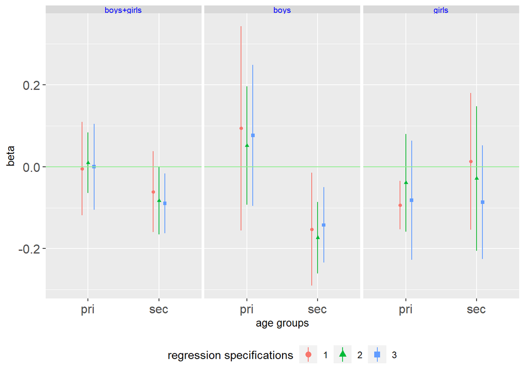

## Placebo

### By gender and by aghh def

2002 cohort

| variables | Boys+girls Spec 1 | Boys+girls Spec 2 | Boys+girls Spec 3 | Boys Spec 1 | Boys Spec 2 | Boys Spec 3 | Girls Spec 1 | Girls Spec 2 | Girls Spec 3 |
| --- | --- | --- | --- | --- | --- | --- | --- | --- | --- |
| **agHH0** |  |  |  |  |  |  |  |  |  |
|  | 1 | 2 | 3 | 4 | 5 | 6 | 7 | 8 | 9 |
| Agricultural households * year 2002 | -0.0530 | -0.0301 | -0.0435 | 0.0036 | -0.0196 | -0.0286 | -0.1057 | -0.0371 | -0.0493 |
|  | (14.2) | (40.6) | (35.7) | (93.5) | (57.9) | (35.6) | (7.9) | (44.4) | (49.3) |
|  | [-0.129, 0.023] | [-0.112, 0.051] | [-0.149, 0.062] | [-0.098, 0.105] | [-0.100, 0.061] | [-0.098, 0.041] | [-0.228, 0.016] | [-0.147, 0.073] | [-0.213, 0.114] |
| ____ * Older sisters |  |  | -0.0711 |  |  | -0.0978 |  |  | -0.0501 |
|  |  |  | (6.4) |  |  | (13.7) |  |  | (20.3) |
|  |  |  | [-0.148, 0.006] |  |  | [-0.239, 0.043] |  |  | [-0.139, 0.039] |
| ____ * Older brothers |  |  | 0.0123 |  |  | 0.0768 |  |  | -0.0437 |
|  |  |  | (71.9) |  |  | (13.3) |  |  | (31.2) |
|  |  |  | [-0.069, 0.094] |  |  | [-0.033, 0.186] |  |  | [-0.143, 0.055] |
| R2 | 0.0030 | 0.2022 | 0.2250 | 0.0000 | 0.1124 | 0.1738 | 0.0115 | 0.3404 | 0.3635 |
| N: Agricultural HHs |  | 492 |  |  | 243 |  |  | 249 |  |
| N |  | 812 |  |  | 386 |  |  | 426 |  |
| Mean of control in 2002 |  | 0.6844 |  |  | 0.6573 |  |  | 0.7062 |  |
| Mean of treated in 2002 |  | 0.5955 |  |  | 0.5391 |  |  | 0.6506 |  |
| Mean of control in 2006 |  | 0.4406 |  |  | 0.3986 |  |  | 0.4746 |  |
| Mean of treated in 2006 |  | 0.2988 |  |  | 0.2840 |  |  | 0.3133 |  |
| **isagHH** |  |  |  |  |  |  |  |  |  |
|  | 10 | 11 | 12 | 13 | 14 | 15 | 16 | 17 | 18 |
| Agricultural households * year 2002 | -0.0461 | -0.0262 | -0.0392 | 0.0130 | -0.0010 | -0.0128 | -0.1020 | -0.0479 | -0.0674 |
|  | (19.3) | (43.8) | (32.5) | (80.6) | (98.1) | (74.6) | (7.6) | (18.1) | (20.6) |
|  | [-0.122, 0.030] | [-0.102, 0.050] | [-0.128, 0.049] | [-0.108, 0.134] | [-0.104, 0.102] | [-0.105, 0.079] | [-0.218, 0.014] | [-0.125, 0.029] | [-0.183, 0.048] |
| ____ * Older sisters |  |  | -0.0700 |  |  | -0.1195 |  |  | -0.0291 |
|  |  |  | (9.6) |  |  | (8.3) |  |  | (48.1) |
|  |  |  | [-0.158, 0.018] |  |  | [-0.261, 0.022] |  |  | [-0.129, 0.070] |
| ____ * Older brothers |  |  | -0.0077 |  |  | 0.0447 |  |  | -0.0503 |
|  |  |  | (83.2) |  |  | (32.8) |  |  | (29.4) |
|  |  |  | [-0.094, 0.079] |  |  | [-0.059, 0.149] |  |  | [-0.159, 0.058] |
| R2 | 0.0023 | 0.2020 | 0.2209 | 0.0002 | 0.1120 | 0.1687 | 0.0110 | 0.3413 | 0.3666 |
| N: Agricultural HHs |  | 456 |  |  | 227 |  |  | 229 |  |
| N |  | 812 |  |  | 386 |  |  | 426 |  |
| Mean of control in 2002 |  | 0.6826 |  |  | 0.6604 |  |  | 0.7005 |  |
| Mean of treated in 2002 |  | 0.5899 |  |  | 0.5286 |  |  | 0.6507 |  |
| Mean of control in 2006 |  | 0.4326 |  |  | 0.3962 |  |  | 0.4619 |  |
| Mean of treated in 2006 |  | 0.2939 |  |  | 0.2775 |  |  | 0.3100 |  |
| **hdagHH** |  |  |  |  |  |  |  |  |  |
|  | 19 | 20 | 21 | 22 | 23 | 24 | 25 | 26 | 27 |
| Agricultural households * year 2002 | -0.0477 | -0.0229 | -0.0367 | -0.0036 | -0.0271 | -0.0455 | -0.0900 | -0.0291 | -0.0494 |
|  | (16.8) | (53.0) | (35.5) | (94.6) | (48.6) | (29.0) | (10.3) | (46.2) | (25.3) |
|  | [-0.121, 0.026] | [-0.105, 0.060] | [-0.125, 0.052] | [-0.127, 0.120] | [-0.115, 0.061] | [-0.140, 0.049] | [-0.204, 0.024] | [-0.119, 0.060] | [-0.144, 0.045] |
| ____ * Older sisters |  |  | -0.0728 |  |  | -0.1016 |  |  | -0.0457 |
|  |  |  | (10.4) |  |  | (10.7) |  |  | (26.4) |
|  |  |  | [-0.167, 0.021] |  |  | [-0.234, 0.031] |  |  | [-0.140, 0.048] |
| ____ * Older brothers |  |  | 0.0033 |  |  | 0.0424 |  |  | -0.0402 |
|  |  |  | (93.2) |  |  | (45.2) |  |  | (42.2) |
|  |  |  | [-0.086, 0.093] |  |  | [-0.087, 0.172] |  |  | [-0.155, 0.074] |
| R2 | 0.0025 | 0.2019 | 0.2197 | 0.0000 | 0.1128 | 0.1631 | 0.0086 | 0.3399 | 0.3688 |
| N: Agricultural HHs |  | 440 |  |  | 217 |  |  | 223 |  |
| N |  | 812 |  |  | 386 |  |  | 426 |  |
| Mean of control in 2002 |  | 0.6747 |  |  | 0.6331 |  |  | 0.7094 |  |
| Mean of treated in 2002 |  | 0.5932 |  |  | 0.5438 |  |  | 0.6413 |  |
| Mean of control in 2006 |  | 0.4247 |  |  | 0.3787 |  |  | 0.4631 |  |
| Mean of treated in 2006 |  | 0.2955 |  |  | 0.2857 |  |  | 0.3049 |  |
| **ocagHH** |  |  |  |  |  |  |  |  |  |
|  | 28 | 29 | 30 | 31 | 32 | 33 | 34 | 35 | 36 |
| Agricultural households * year 2002 | -0.0383 | -0.0345 | -0.0514 | -0.0083 | -0.0163 | -0.0382 | -0.0721 | -0.0434 | -0.0416 |
|  | (35.9) | (40.9) | (25.6) | (86.1) | (71.4) | (29.0) | (26.3) | (40.4) | (47.5) |
|  | [-0.131, 0.054] | [-0.128, 0.059] | [-0.150, 0.047] | [-0.117, 0.100] | [-0.118, 0.085] | [-0.118, 0.042] | [-0.213, 0.069] | [-0.160, 0.073] | [-0.173, 0.090] |
| ____ * Older sisters |  |  | -0.0745 |  |  | -0.1130 |  |  | -0.0417 |
|  |  |  | (5.7) |  |  | (7.3) |  |  | (32.0) |
|  |  |  | [-0.152, 0.003] |  |  | [-0.241, 0.015] |  |  | [-0.140, 0.057] |
| ____ * Older brothers |  |  | -0.0081 |  |  | 0.0373 |  |  | -0.0681 |
|  |  |  | (80.5) |  |  | (38.9) |  |  | (8.4) |
|  |  |  | [-0.085, 0.069] |  |  | [-0.062, 0.137] |  |  | [-0.149, 0.013] |
| R2 | 0.0016 | 0.2026 | 0.2256 | 0.0001 | 0.1123 | 0.1758 | 0.0055 | 0.3409 | 0.3666 |
| N: Agricultural HHs |  | 436 |  |  | 227 |  |  | 209 |  |
| N |  | 812 |  |  | 386 |  |  | 426 |  |
| Mean of control in 2002 |  | 0.6729 |  |  | 0.6415 |  |  | 0.6959 |  |
| Mean of treated in 2002 |  | 0.5940 |  |  | 0.5419 |  |  | 0.6507 |  |
| Mean of control in 2006 |  | 0.4176 |  |  | 0.3899 |  |  | 0.4378 |  |
| Mean of treated in 2006 |  | 0.3005 |  |  | 0.2819 |  |  | 0.3206 |  |
| **Common specifications** |  |  |  |  |  |  |  |  |  |
| Thana fixed trends |  | Y | Y |  | Y | Y |  | Y | Y |
| HH fixed trends |  |  | Y |  |  | Y |  |  | Y |

Note:

Sample of direct offspring of household heads.

<sup>1</sup> For each panel, first and fourth columns are raw DID. Second and fifth columns add time-varying thana level characteristics (yield, mean rainfall, mean high temperature, mean low temperature), individual level characteristics (age squared, recipient of a poverty program), and Thana fixed trends that are interactions of year 2002 dummy with Thana fixed effects. Third and sixth columns add interactions of year 2002 dummy and individual level characterstics (sex of individual, household head’s and spouse’s education, number of older male/female siblings, per member land holding, per member non land asset holding, piped water access, structured toilet access) $\bfx_{i}r_{t}$, and triple interactions of year 2002 dummy, individual characteristics, and agricultural household dummy $\bfx_{i}r_{t}D_{i}$.

<sup>2</sup> Standard errors are clusterd at thana level using bias-reduced linearization (Satterthwaite correction) for a correction of small number of clusters. $P$ values in percentages are shown in parethenses. 95% confidence intervals are shown in square brackets. $*$, $**$, $***$ indicate significance levels at 10%, 5%, 1% under BRL cluster robust standard errors, respectively.

1999 cohort

| variables | Boys+girls Spec 1 | Boys+girls Spec 2 | Boys+girls Spec 3 | Boys Spec 1 | Boys Spec 2 | Boys Spec 3 | Girls Spec 1 | Girls Spec 2 | Girls Spec 3 |
| --- | --- | --- | --- | --- | --- | --- | --- | --- | --- |
| **agHH0** |  |  |  |  |  |  |  |  |  |
|  | 1 | 2 | 3 | 4 | 5 | 6 | 7 | 8 | 9 |
| Agricultural households * year 2002 | -0.0233 | -0.0312 | -0.0326 | 0.0302 | 0.0075 | 0.0008 | -0.0844 | -0.0576 | -0.0690 |
|  | (61.1) | (22.9) | (39.5) | (55.0) | (87.2) | (98.7) | (27.5) | (28.1) | (27.8) |
|  | [-0.128, 0.082] | [-0.088, 0.026] | [-0.120, 0.054] | [-0.086, 0.146] | [-0.101, 0.116] | [-0.114, 0.116] | [-0.256, 0.087] | [-0.177, 0.062] | [-0.212, 0.074] |
| ____ * Older sisters |  |  | -0.0532 |  |  | 0.0148 |  |  | -0.0971 |
|  |  |  | (36.5) |  |  | (83.8) |  |  | (25.0) |
|  |  |  | [-0.195, 0.089] |  |  | [-0.167, 0.196] |  |  | [-0.295, 0.100] |
| ____ * Older brothers |  |  | -0.0025 |  |  | 0.0334 |  |  | -0.0377 |
|  |  |  | (96.1) |  |  | (65.4) |  |  | (42.2) |
|  |  |  | [-0.129, 0.124] |  |  | [-0.154, 0.221] |  |  | [-0.150, 0.075] |
| R2 | 0.0006 | 0.2930 | 0.3208 | 0.0011 | 0.1051 | 0.1628 | 0.0076 | 0.4895 | 0.5205 |
| N: Agricultural HHs |  | 379 |  |  | 196 |  |  | 183 |  |
| N |  | 616 |  |  | 304 |  |  | 312 |  |
| Mean of control in 2002 |  | 0.4979 |  |  | 0.4722 |  |  | 0.5194 |  |
| Mean of treated in 2002 |  | 0.3852 |  |  | 0.2908 |  |  | 0.4863 |  |
| Mean of control in 2006 |  | 0.2785 |  |  | 0.2685 |  |  | 0.2868 |  |
| Mean of treated in 2006 |  | 0.1425 |  |  | 0.1173 |  |  | 0.1694 |  |
| **isagHH** |  |  |  |  |  |  |  |  |  |
|  | 10 | 11 | 12 | 13 | 14 | 15 | 16 | 17 | 18 |
| Agricultural households * year 2002 | -0.0067 | -0.0202 | -0.0177 | 0.0506 | 0.0349 | 0.0303 | -0.0760 | -0.0581 | -0.0702 |
|  | (90.0) | (46.8) | (62.3) | (44.9) | (54.3) | (58.3) | (33.8) | (23.4) | (24.3) |
|  | [-0.130, 0.117] | [-0.084, 0.043] | [-0.101, 0.066] | [-0.101, 0.202] | [-0.096, 0.166] | [-0.099, 0.159] | [-0.253, 0.101] | [-0.165, 0.049] | [-0.204, 0.063] |
| ____ * Older sisters |  |  | -0.0585 |  |  | -0.0046 |  |  | -0.0781 |
|  |  |  | (30.3) |  |  | (94.8) |  |  | (35.6) |
|  |  |  | [-0.191, 0.074] |  |  | [-0.179, 0.169] |  |  | [-0.279, 0.123] |
| ____ * Older brothers |  |  | -0.0112 |  |  | 0.0038 |  |  | -0.0327 |
|  |  |  | (81.5) |  |  | (95.9) |  |  | (50.6) |
|  |  |  | [-0.127, 0.105] |  |  | [-0.183, 0.191] |  |  | [-0.151, 0.085] |
| R2 | 0.0001 | 0.2924 | 0.3215 | 0.0032 | 0.1063 | 0.1622 | 0.0063 | 0.4897 | 0.5191 |
| N: Agricultural HHs |  | 355 |  |  | 188 |  |  | 167 |  |
| N |  | 616 |  |  | 304 |  |  | 312 |  |
| Mean of control in 2002 |  | 0.5019 |  |  | 0.4828 |  |  | 0.5172 |  |
| Mean of treated in 2002 |  | 0.3746 |  |  | 0.2766 |  |  | 0.4850 |  |
| Mean of control in 2006 |  | 0.2720 |  |  | 0.2672 |  |  | 0.2759 |  |
| Mean of treated in 2006 |  | 0.1380 |  |  | 0.1117 |  |  | 0.1677 |  |
| **hdagHH** |  |  |  |  |  |  |  |  |  |
|  | 19 | 20 | 21 | 22 | 23 | 24 | 25 | 26 | 27 |
| Agricultural households * year 2002 | -0.0216 | -0.0278 | -0.0342 | 0.0192 | -0.0112 | -0.0170 | -0.0703 | -0.0471 | -0.0664 |
|  | (63.3) | (37.9) | (31.4) | (76.1) | (81.7) | (72.4) | (31.1) | (31.0) | (19.0) |
|  | [-0.125, 0.082] | [-0.099, 0.043] | [-0.110, 0.041] | [-0.126, 0.164] | [-0.123, 0.100] | [-0.129, 0.095] | [-0.224, 0.084] | [-0.151, 0.057] | [-0.177, 0.044] |
| ____ * Older sisters |  |  | -0.0699 |  |  | -0.0059 |  |  | -0.0812 |
|  |  |  | (16.0) |  |  | (90.0) |  |  | (37.1) |
|  |  |  | [-0.180, 0.040] |  |  | [-0.121, 0.109] |  |  | [-0.299, 0.137] |
| ____ * Older brothers |  |  | -0.0093 |  |  | 0.0020 |  |  | -0.0436 |
|  |  |  | (86.6) |  |  | (98.0) |  |  | (46.0) |
|  |  |  | [-0.140, 0.121] |  |  | [-0.191, 0.195] |  |  | [-0.182, 0.094] |
| R2 | 0.0005 | 0.2928 | 0.3199 | 0.0005 | 0.1052 | 0.1515 | 0.0054 | 0.4885 | 0.5218 |
| N: Agricultural HHs |  | 341 |  |  | 176 |  |  | 165 |  |
| N |  | 616 |  |  | 304 |  |  | 312 |  |
| Mean of control in 2002 |  | 0.4909 |  |  | 0.4453 |  |  | 0.5306 |  |
| Mean of treated in 2002 |  | 0.3783 |  |  | 0.2898 |  |  | 0.4727 |  |
| Mean of control in 2006 |  | 0.2691 |  |  | 0.2500 |  |  | 0.2857 |  |
| Mean of treated in 2006 |  | 0.1349 |  |  | 0.1136 |  |  | 0.1576 |  |
| **ocagHH** |  |  |  |  |  |  |  |  |  |
|  | 28 | 29 | 30 | 31 | 32 | 33 | 34 | 35 | 36 |
| Agricultural households * year 2002 | 0.0086 | -0.0080 | -0.0087 | 0.0268 | 0.0329 | 0.0192 | -0.0256 | -0.0393 | -0.0307 |
|  | (84.1) | (77.0) | (83.3) | (67.0) | (54.9) | (74.9) | (67.6) | (39.2) | (60.6) |
|  | [-0.089, 0.107] | [-0.071, 0.055] | [-0.104, 0.087] | [-0.117, 0.171] | [-0.091, 0.157] | [-0.120, 0.158] | [-0.166, 0.115] | [-0.142, 0.064] | [-0.169, 0.107] |
| ____ * Older sisters |  |  | -0.0541 |  |  | -0.0157 |  |  | -0.0704 |
|  |  |  | (34.0) |  |  | (80.9) |  |  | (36.0) |
|  |  |  | [-0.188, 0.080] |  |  | [-0.175, 0.143] |  |  | [-0.253, 0.113] |
| ____ * Older brothers |  |  | -0.0128 |  |  | 0.0025 |  |  | -0.0463 |
|  |  |  | (79.0) |  |  | (97.0) |  |  | (27.4) |
|  |  |  | [-0.127, 0.101] |  |  | [-0.163, 0.168] |  |  | [-0.142, 0.050] |
| R2 | 0.0001 | 0.2921 | 0.3185 | 0.0009 | 0.1062 | 0.1683 | 0.0007 | 0.4880 | 0.5167 |
| N: Agricultural HHs |  | 335 |  |  | 179 |  |  | 156 |  |
| N |  | 616 |  |  | 304 |  |  | 312 |  |
| Mean of control in 2002 |  | 0.4875 |  |  | 0.4480 |  |  | 0.5192 |  |
| Mean of treated in 2002 |  | 0.3791 |  |  | 0.2905 |  |  | 0.4808 |  |
| Mean of control in 2006 |  | 0.2491 |  |  | 0.2480 |  |  | 0.2500 |  |
| Mean of treated in 2006 |  | 0.1493 |  |  | 0.1173 |  |  | 0.1859 |  |
| **Common specifications** |  |  |  |  |  |  |  |  |  |
| Thana fixed trends |  | Y | Y |  | Y | Y |  | Y | Y |
| HH fixed trends |  |  | Y |  |  | Y |  |  | Y |

Note:

Sample of direct offspring of household heads.

<sup>1</sup> For each panel, first and fourth columns are raw DID. Second and fifth columns add time-varying thana level characteristics (yield, mean rainfall, mean high temperature, mean low temperature), individual level characteristics (age squared, recipient of a poverty program), and Thana fixed trends that are interactions of year 2002 dummy with Thana fixed effects. Third and sixth columns add interactions of year 2002 dummy and individual level characterstics (sex of individual, household head’s and spouse’s education, number of older male/female siblings, per member land holding, per member non land asset holding, piped water access, structured toilet access) $\bfx_{i}r_{t}$, and triple interactions of year 2002 dummy, individual characteristics, and agricultural household dummy $\bfx_{i}r_{t}D_{i}$.

<sup>2</sup> Standard errors are clusterd at thana level using bias-reduced linearization (Satterthwaite correction) for a correction of small number of clusters. $P$ values in percentages are shown in parethenses. 95% confidence intervals are shown in square brackets. $*$, $**$, $***$ indicate significance levels at 10%, 5%, 1% under BRL cluster robust standard errors, respectively.

# Memo on FD and DID

FD and raw DID are numerically identical in a two-period panel. If we add covariates, FD automatically controls for individual FEs while DID needs explicit inclusion of individual dummy variables. Without including individual dummy variables, correlations of individual FEs with other covariates affect the value of estimates thus FD and DID estimates will differ. Unfortunately, adding FEs at the individual level, with the order of hundreds to thousands, is practically infeasible to implement in estimation. So most econometric and statistical programs use FE implementation.